# Sociodemographic Disparities in Pediatric Emergency Department Revisit Rates

BMIN503/EPID600 Final Project

Author

Casey E. Pitts

## 1 Overview

**Area of Interest:**  
Are there sociodemographic disparities in the rate of pediatric emergency room short-term revisits (re-presenting to the ED within 72 hours)?

**Mentors:**  
Joseph Zorc, MD, MSCE. Professor of Pediatrics, Mark Fishman Endowed Chair in Genomics and Computational Science, and Director of Emergency Information Systems. Division of Emergency Medicine, Department of Pediatrics, Children’s Hospital of Philadelphia.

- Reviewed key factors of interest, including demographics, language proficiency, acuity, admission status, as well as clearly defining the “revisit” variable

Brandon C. Ku, MD. Associate Professor of Pediatrics, Associate Medical Director of Clinical Pathways Program, and Associate Director of Quality Improvement. Divison of Emergency Medicine, Department of Pediatrics, Children’s Hospital of Philadelphia.

- Discussed primary and secondary outcome measures of the project as well as the optimal visualizations of the variables of interest.

## 2 Introduction

Pediatric emergency care (PEC) is a complex and fast-paced environment that treats patients across the healthcare and socio-demographic spectrums. Recently, there has been increasing focus on overall care quality and disparities in PEC. Disparities are known to exist in timely pain management by patient race and that those with non-English language proficiency have an increased risk of adverse medical events. Revisits, or returning to the emergency department within 72 hours, are an important marker of care quality and performance indicator of a department. While patients represent to the emergency room following a visit for various reasons, including progression of disease or repeat medication administration, it may signal incomplete ED care or insufficient anticipatory guidance. Revisits are also associated with increased healthcare costs, over-crowding and system stress, and decreased satisfaction of both families and staff.

Understanding the disparities associated with increased revisit rates and discovering modifiable factors is needed to offer solutions. This study will examine the association of sociodemographic and visit-specific factors that are associated with revisits that result either in a repeat discharge or hospitalization.

## 3 Methods

This is a retrospective study of patients, between 0-18 years old, presenting to a urban, tertiary, academic pediatric emergency department between November 01, 2021 to November 01, 2023. We calculated rates of 72 hour revisits resulting in repeat discharge or hospital admission. Both patient and visit-level factors were included for exploratory analysis. Visit-level factors include daily volume, daily average acuity, daily average wait time, and ED location. Patient-level factors include age, sex, race, ethnicity, preferred language, individual triage acuity, history of complex medical conditions, chief complaint, insurance status, COI, distance from the ED, and green space access.

Data was accessed through the institutional data warehouse, extracted from patient and encounter-level tables and downloaded as a CSV file.

### 3.1 Install Packages

```r
install.packages("tidyverse")
install.packages("expss")
install.packages("tidymodels")
install.packages("ggplot2")
install.packages("cowplot")
install.packages("lubridate")
install.packages("gtsummary")
install.packages("dplyr")
install.packages("paletteer")
install.packages("ggthemes")
install.packages("pROC")
```

### 3.2 Load Packages

### 3.3 Read in & Clean the Data

```r
#Read in CSV File
data<- read.csv("./EDRevisits.csv")

#Convert data types as needed
data[data=='']<-NA
data$ENCOUNTER_DATE <- mdy(data$ENCOUNTER_DATE)
data$WAITTIME<- period_to_seconds(hms(data$WAITTIME))
data$ARRIVALTIME<- lubridate::hms(data$ARRIVALTIME)
data$DAILYVISITS<- as.numeric(as.integer(data$DAILYVISITS))

#Convert Wait Time from HMS to Minutes
data<- data|>
  mutate(waitmin = WAITTIME/60)
```

#### 3.3.1 Additional Cleaning

```r
#Race/Ethnicity Category Collapse & Factor
data<- data|>
  mutate (eth_cat = (case_when(
    str_detect(RACE_ETHNICITY, "White") ~ "White",
    str_detect(RACE_ETHNICITY, "Black") ~ "Black",
    str_detect(RACE_ETHNICITY, "Asian") ~ "Other",
    str_detect(RACE_ETHNICITY, "Latino") ~ "Hispanic/Latino",
    str_detect(RACE_ETHNICITY, "Multi") ~ "Other",
    str_detect(RACE_ETHNICITY, "Other") ~ "Other",
    str_detect(RACE_ETHNICITY, "Native") ~ "Other",
    str_detect(RACE_ETHNICITY, "nknown") ~ "Other",
    str_detect(RACE_ETHNICITY, "Refused") ~ "Other",
    str_detect(RACE_ETHNICITY, "disclose") ~ "Other",
      )))|>
  mutate (eth_cat = factor(eth_cat, levels = c("White", "Black", "Hispanic/Latino", "Other"), labels = c("White", "Black", "Hispanic/Latino", "Other")))

#Convert ED Volume to Categorical
data<- data |>
  mutate (volume = case_when(
    CAMPUS == "Main" & DAILYVISITS <=244 ~ "Low",
    CAMPUS == "Main" & DAILYVISITS <=277 ~ "Medium-Low",
    CAMPUS == "Main" & DAILYVISITS <=307 ~ "Medium-High",
    CAMPUS == "Main" & DAILYVISITS >307 ~ "High",
    CAMPUS == "Community" & DAILYVISITS <=90 ~ "Low",
    CAMPUS == "Community" & DAILYVISITS <=103 ~ "Medium-Low",
    CAMPUS == "Community" & DAILYVISITS <=114 ~ "Medium-High",
    CAMPUS == "Community" & DAILYVISITS >296 ~ "High"))

#Collapse Arrival Times to 3 Categories
data<- data |>
  mutate (Arrival = case_when(
    hour(ARRIVALTIME) >= 23 ~ "Overnight",
    hour(ARRIVALTIME) >= 15 ~"Evening",
    hour(ARRIVALTIME) >=7 ~ "Daytime",
    hour(ARRIVALTIME) < 7 ~ "Overnight"
  ))

#Age to Dichotomous
data<- data |>
  mutate (age_cat = case_when(
    AGE_AT_VISIT < 1 ~ "Infant",
    AGE_AT_VISIT >=1 ~ "Child/Teen"))

#ED Disposition to Dichotomous
data<- data |>
  mutate (ED_DISPOSITION = case_when(
    str_detect(ED_DISPOSITION, "Discharge") ~ "Discharge",
    str_detect(ED_DISPOSITION, "AMA") ~ "AMA/Eloped",
    str_detect(ED_DISPOSITION, "Left Before Discharge (Eloped)") ~ "AMA/Eloped"))

#Acuity to Dichotomous
data<- data |>
  mutate (esigp = case_when(
    ACUITY >= 1 & ACUITY <= 3  ~ "Acute",
    ACUITY >=4 & ACUITY <= 5 ~ "Non-Urgent"))

#Factor
data<- data |>
  mutate(REVISIT_72_HR = factor(REVISIT_72_HR, levels = c(0,1),
                                labels = c("No Revisit", "Revisit")))|>
  mutate(LANGIND = factor(LANGIND, levels = c(1,0),
                          labels = c("English","Other")))|>
  mutate(PCP_VISIT_72_HR = factor(PCP_VISIT_72_HR, levels = c(0,1),
                            labels = c("No PCP Visit", "PCP Visit"))) |>
  mutate(READMIT_72_HR = factor(READMIT_72_HR, levels = c(0, 1),
                         labels = c("Re-discharged", "Admitted"))) |>
  mutate(SEX = factor(SEX, levels = c("M", "F"),
                      labels = c("Male", "Female"))) |>
  mutate(COMPLEX_CHRONIC_CONDITION_IND = factor(COMPLEX_CHRONIC_CONDITION_IND,
                      levels = c(0,1),
                      labels = c("None", "Chronic/Complex"))) |>
  mutate(ACUITY = factor(ACUITY)) |>
  mutate(ED_DISPOSITION = factor(ED_DISPOSITION, levels = c("Discharge", "AMA/Eloped"), labels = c("Discharge", "AMA/Eloped")))|>
  mutate(CAMPUS = factor(CAMPUS, levels = c("Main", "Community"),
                         labels = c("Main", "Community")))|>
  mutate(age_cat = factor(age_cat))|>
  mutate(Arrival = factor(Arrival))|>
  mutate(PAYOR_GROUP = factor(PAYOR_GROUP, levels = c("COMMERCIAL", "GOVERNMENT", "CHARITY CARE", "SELF PAY"),
                              labels = c("Commercial", "Government", "Charity Care", "Self Pay")))|>
  mutate(SVI_CATEGORY = factor(SVI_CATEGORY))|>
  mutate(esigp = factor(esigp))|>
  mutate(volume = factor(volume))

#Rename Columns
data <- data|>
  apply_labels(
          ENCOUNTER_DATE = "Date",
          SEX = "Sex",
          DAILYVISITS = "Total Daily Visits",
          AVGESI = "Average Daily Acuity",
          WAITTIME = "Average Daily Wait Time",
          AGE_AT_VISIT = "Age",
          RACE_ETHNICITY = "Race & Ethnicity",
          LANGIND = "Language",
          PAYOR_GROUP = "Insurance Type",
          SVI_CATEGORY = "Vulnerability Score",
          PATIENT_ADDRESS_ZIP_CODE = "Zip Code",
          ED_LOS = "Length of Stay",
          REVISIT_72_HR = "Revisit within 72 Hours",
          READMIT_72_HR = "Admission within 72 Hours",
          COMPLEX_CHRONIC_CONDITION_IND = "Complex or Chronic History",
          ED_DISPOSITION = "Disposition from ED",
          PCP_VISIT_72_HR = "PCP Visit within 72 Hours",
          eth_cat = "Race/Ethnicity",
          CAMPUS = "Campus",
          waitmin = "Average Daily Wait Time (in minutes)",
          ACUITY = "Acuity",
          age_cat = "Age (Categorical)",
          esigp = "Acuity (Dichotomized)",
          volume = "ED Volume (Categorical)"
          )
```

## 4 Results

### 4.1 Summary Statistics

```r
#Overall Emergency Department Summary
tbl_summary(data, include = c(DAILYVISITS, AVGESI, waitmin),
      statistic = list(
      all_continuous() ~ "{mean} ({sd})",
      all_categorical() ~ "{n} / {N} ({p}%)"
    ),
            by = CAMPUS,
    missing = "no")|>
  modify_caption ("**Table 1: Emergency Department Characteristics**") |>
  modify_header (label = "") |>
  bold_labels()
```

**Table 1: Emergency Department Characteristics**

|  | **Main**, N = 157,524<sup>1</sup> | **Community**, N = 54,060<sup>1</sup> |
| --- | --- | --- |
| Total Daily Visits | 275 (43) | 102 (17) |
| Average Daily Acuity | 3.21 (0.08) | 3.13 (0.12) |
| Average Daily Wait Time (in minutes) | 49 (41) | 53 (47) |

<sup>1</sup> Mean (SD)

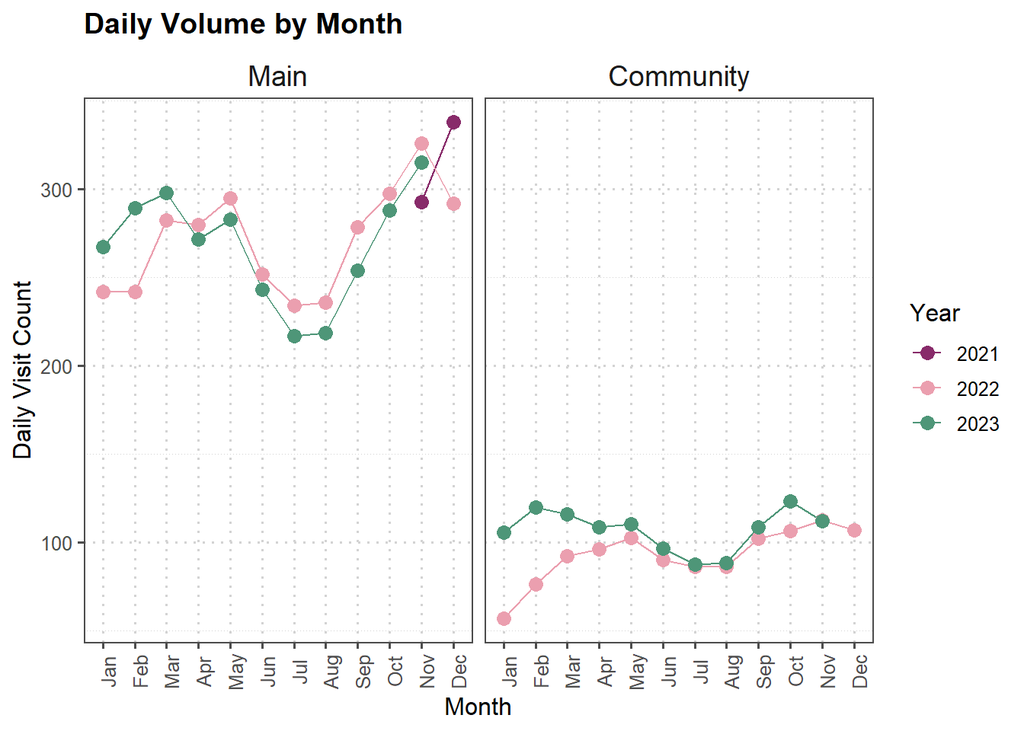

```r
#Plot Average Daily Volume by Month
VisitsbyMonth <- data |>
  group_by(CAMPUS, Year = as.character(year(ENCOUNTER_DATE)), month = month(ENCOUNTER_DATE, label = TRUE)) |>
      summarise(avg = mean(DAILYVISITS))
ggplot(VisitsbyMonth, aes(x =month, y = avg, color = Year)) +
  geom_line(aes(group = Year)) +
  geom_point(size = 3) +
  facet_grid(~CAMPUS) +
  theme_few() +
  ggtitle("Daily Volume by Month") +
  theme(plot.title =element_text(face = "bold"),
        strip.text.x = element_text(size = 14),
        panel.grid = element_line(color = "lightgrey",linetype = "dotted"))+
  theme(axis.text.x  = element_text(angle=90, vjust=0.8)) +
  labs(x = "Month", y = "Daily Visit Count") +
  scale_color_paletteer_d("futurevisions::jupiter")
```

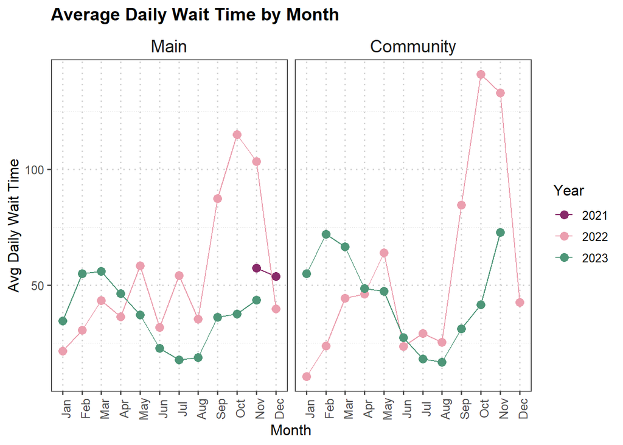

```r
#Plot Average Wait Time by Month
WaitbyMonth <- data |>
  group_by(CAMPUS, Year = as.character(year(ENCOUNTER_DATE)), month = month(ENCOUNTER_DATE, label = TRUE)) |>
      summarise(avg = mean(waitmin))
ggplot(WaitbyMonth, aes(x =month, y = avg, color = Year)) +
  geom_line(aes(group = Year)) +
  geom_point(size = 3) +
  facet_grid(~CAMPUS) +
  theme_few() +
  ggtitle("Average Daily Wait Time by Month") +
  theme(plot.title =element_text(face = "bold"),
        strip.text.x = element_text(size = 14),
        panel.grid = element_line(color = "lightgrey",linetype = "dotted"))+
  theme(axis.text.x  = element_text(angle=90, vjust=0.8)) +
  labs(x = "Month", y = "Avg Daily Wait Time") +
  scale_color_paletteer_d("futurevisions::jupiter")
```

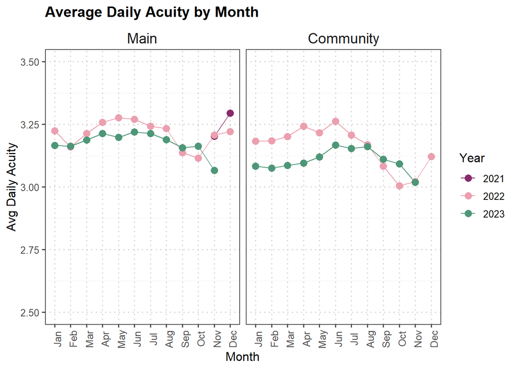

```r
#Plot Average Daily Acuity by Month
AcuitybyMonth <- data |>
  group_by(CAMPUS, Year = as.character(year(ENCOUNTER_DATE)), month = month(ENCOUNTER_DATE, label = TRUE)) |>
      summarise(avg = mean(AVGESI))
ggplot(AcuitybyMonth, aes(x =month, y = avg, color = Year)) +
  geom_line(aes(group = Year)) +
  geom_point(size = 3) +
  facet_grid(~CAMPUS) +
  theme_few() +
  ggtitle("Average Daily Acuity by Month") +
  theme(plot.title =element_text(face = "bold"),
        strip.text.x = element_text(size = 14),
        panel.grid = element_line(color = "lightgrey",linetype = "dotted"))+
  theme(axis.text.x  = element_text(angle=90, vjust=0.8)) +
  theme(plot.title =element_text(face = "bold"))+
  labs(x = "Month", y = "Avg Daily Acuity") +
  ylim (low = 2.5, high = 3.5)+
  scale_color_paletteer_d("futurevisions::jupiter")
```

```r
#Descriptive Statistics
data|>
  select(SEX, AGE_AT_VISIT, eth_cat, LANGIND, PAYOR_GROUP, SVI_CATEGORY, ACUITY, COMPLEX_CHRONIC_CONDITION_IND, CAMPUS, ED_LOS, Arrival, ED_DISPOSITION, READMIT_72_HR, REVISIT_72_HR)|>
  tbl_strata2(
    strata = CAMPUS,
    .tbl_fun =
    ~.x |>
tbl_summary(missing_text = "NA",
            by = REVISIT_72_HR,
            missing = "no") |>
  modify_caption ("**Table 2: Patient Characteristics**") |>
  modify_header (label = "**Variable**") |>
  bold_labels()
)
```

**Table 2: Patient Characteristics**

| **Variable** | **Main** **No Revisit**, N = 150,586<sup>1</sup> | **Main** **Revisit**, N = 6,938<sup>1</sup> | **Community** **No Revisit**, N = 51,302<sup>1</sup> | **Community** **Revisit**, N = 2,758<sup>1</sup> |
| --- | --- | --- | --- | --- |
| Sex |  |  |  |  |
| Male | 78,492 (52%) | 3,646 (53%) | 27,718 (54%) | 1,467 (53%) |
| Female | 72,083 (48%) | 3,292 (47%) | 23,582 (46%) | 1,291 (47%) |
| Age | 5.1 (2.0, 10.7) | 3.7 (1.4, 9.0) | 5.2 (2.0, 10.7) | 4.2 (1.4, 9.4) |
| Race/Ethnicity |  |  |  |  |
| White | 26,571 (18%) | 1,231 (18%) | 28,276 (55%) | 1,573 (57%) |
| Black | 81,422 (54%) | 3,638 (52%) | 6,666 (13%) | 343 (12%) |
| Hispanic/Latino | 22,424 (15%) | 1,086 (16%) | 7,193 (14%) | 397 (14%) |
| Other | 20,164 (13%) | 983 (14%) | 9,166 (18%) | 445 (16%) |
| Language |  |  |  |  |
| English | 136,875 (91%) | 6,316 (91%) | 47,263 (92%) | 2,567 (93%) |
| Other | 13,711 (9.1%) | 622 (9.0%) | 4,039 (7.9%) | 191 (6.9%) |
| Insurance Type |  |  |  |  |
| Commercial | 40,456 (27%) | 1,737 (25%) | 33,260 (65%) | 1,777 (65%) |
| Government | 107,923 (72%) | 5,134 (74%) | 17,538 (34%) | 958 (35%) |
| Charity Care | 201 (0.1%) | 9 (0.1%) | 29 (<0.1%) | 0 (0%) |
| Self Pay | 1,944 (1.3%) | 55 (0.8%) | 447 (0.9%) | 18 (0.7%) |
| Vulnerability Score |  |  |  |  |
| Highest | 68,480 (50%) | 3,076 (49%) | 4,824 (11%) | 245 (9.9%) |
| Lowest | 15,613 (11%) | 710 (11%) | 24,453 (53%) | 1,305 (53%) |
| Medium high | 34,704 (25%) | 1,675 (27%) | 4,703 (10%) | 261 (11%) |
| Medium low | 17,551 (13%) | 839 (13%) | 11,740 (26%) | 671 (27%) |
| Acuity |  |  |  |  |
| 1 | 123 (<0.1%) | 3 (<0.1%) | 38 (<0.1%) | 4 (0.1%) |
| 2 | 21,758 (14%) | 1,415 (20%) | 8,419 (16%) | 562 (20%) |
| 3 | 49,203 (33%) | 2,466 (36%) | 22,289 (43%) | 1,336 (48%) |
| 4 | 76,457 (51%) | 2,970 (43%) | 19,740 (38%) | 810 (29%) |
| 5 | 3,038 (2.0%) | 83 (1.2%) | 813 (1.6%) | 46 (1.7%) |
| Complex or Chronic History |  |  |  |  |
| None | 130,241 (86%) | 5,588 (81%) | 45,715 (89%) | 2,312 (84%) |
| Chronic/Complex | 20,345 (14%) | 1,350 (19%) | 5,587 (11%) | 446 (16%) |
| Length of Stay | 192 (123, 289) | 217 (142, 317) | 205 (137, 296) | 217 (146, 315) |
| Arrival |  |  |  |  |
| Daytime | 59,960 (40%) | 2,653 (38%) | 21,168 (41%) | 1,100 (40%) |
| Evening | 69,803 (46%) | 3,138 (45%) | 24,077 (47%) | 1,265 (46%) |
| Overnight | 20,823 (14%) | 1,147 (17%) | 6,057 (12%) | 393 (14%) |
| Disposition from ED |  |  |  |  |
| Discharge | 150,551 (100%) | 6,929 (100%) | 51,293 (100%) | 2,754 (100%) |
| AMA/Eloped | 35 (<0.1%) | 9 (0.1%) | 9 (<0.1%) | 4 (0.1%) |
| Admission within 72 Hours |  |  |  |  |
| Re-discharged | 150,586 (100%) | 5,216 (75%) | 51,302 (100%) | 1,940 (70%) |
| Admitted | 0 (0%) | 1,722 (25%) | 0 (0%) | 818 (30%) |

<sup>1</sup> n (%); Median (IQR)

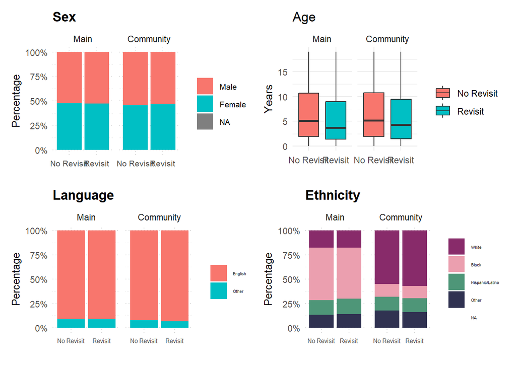

```r
# Sex
sexplot <- ggplot(data, aes(x = factor(REVISIT_72_HR), fill = SEX)) +
  geom_bar(position = "fill") +
  scale_y_continuous(labels = scales::percent) +
  ylab("Percentage")+
  xlab("")+
  labs(title = "Sex")+
  theme_minimal()+
  facet_grid(~CAMPUS) +
  theme(plot.title =element_text(face = "bold"),
        #strip.text.x = element_text(size = 14),
        panel.grid = element_line(color = "lightgrey",linetype = "dotted"))+
  theme(axis.text.x = element_text(size=8),
        axis.title.x = element_text(size=8),
       legend.title = element_blank(),
        legend.text = element_text(size=8),
        axis.title.y = element_text(size=10))

# Language
langplot <- ggplot(data, aes(x = factor(REVISIT_72_HR), fill = factor(LANGIND))) +
  geom_bar(position = "fill") +
  scale_y_continuous(labels = scales::percent) +
  ylab("Percentage")+
  xlab("")+
  labs(title = "Language")+
  theme_minimal()+
  facet_grid(~CAMPUS) +
  theme(plot.title =element_text(face = "bold"),
       # strip.text.x = element_text(size = 14),
        panel.grid = element_line(color = "lightgrey",linetype = "dotted"))+
  theme(axis.text.x = element_text(size=6),
        axis.title.x = element_text(size=10),
        legend.title = element_blank(),
        legend.text = element_text(size=4),
        axis.title.y = element_text(size=10))


# Insurance
insuranceplot<- ggplot(data, aes(x = factor(REVISIT_72_HR), fill = PAYOR_GROUP)) +
  geom_bar(position = "fill") +
  scale_y_continuous(labels = scales::percent) +
  ylab("Percentage")+
  xlab("")+
  labs(title = "Insurance")+
  scale_color_paletteer_d("futurevisions::jupiter")+
  theme_minimal()+
  facet_grid(~CAMPUS) +
    theme(plot.title =element_text(face = "bold"),
        #strip.text.x = element_text(size = 14),
        panel.grid = element_line(color = "lightgrey",linetype = "dotted"))+
  theme(axis.text.x = element_text(size=6),
        axis.title.x = element_text(size=10),
        legend.title = element_blank(),
        legend.text = element_text(size=4),
        axis.title.y = element_text(size=10))

# Acuity (Categorical)
acuityplot<- ggplot(data, aes(x = factor(REVISIT_72_HR), fill = factor(ACUITY))) +
  geom_bar(position = "fill") +
  scale_y_continuous(labels = scales::percent) +
  ylab("Percentage")+
  xlab("")+
  labs(title = "Acuity")+
  theme_minimal()+
  facet_grid(~CAMPUS) +
    theme(plot.title =element_text(face = "bold"),
        #strip.text.x = element_text(size = 14),
        panel.grid = element_line(color = "lightgrey",linetype = "dotted"))+
  theme(axis.text.x = element_text(size=6),
        axis.title.x = element_text(size=10),
        legend.title = element_blank(),
        legend.text = element_text(size=4),
        axis.title.y = element_text(size=10))+
  scale_fill_paletteer_d("futurevisions::jupiter")

#Acuity(Dichotomous)
esigpplot<- ggplot(data, aes(x = factor(REVISIT_72_HR), fill = factor(esigp))) +
  geom_bar(position = "fill") +
  scale_y_continuous(labels = scales::percent) +
  ylab("Percentage")+
  xlab("")+
  labs(title = "Acuity")+
  theme_minimal()+
  facet_grid(~CAMPUS) +
    theme(plot.title =element_text(face = "bold"),
       # strip.text.x = element_text(size = 14),
        panel.grid = element_line(color = "lightgrey",linetype = "dotted"))+
  theme(axis.text.x = element_text(size=6),
        axis.title.x = element_text(size=10),
        legend.title = element_blank(),
        legend.text = element_text(size=4),
        axis.title.y = element_text(size=10))

# Vulnerability Status
sviplot<- ggplot(data, aes(x = factor(REVISIT_72_HR), fill = SVI_CATEGORY)) +
  geom_bar(position = "fill") +
  scale_y_continuous(labels = scales::percent) +
  ylab("Percentage")+
  xlab("")+
  labs(title = "Vulnerability Status")+
  theme_minimal()+
  facet_grid(~CAMPUS) +
    theme(plot.title =element_text(face = "bold"),
       # strip.text.x = element_text(size = 14),
        panel.grid = element_line(color = "lightgrey",linetype = "dotted"))+
  theme(axis.text.x = element_text(size=6),
        axis.title.x = element_text(size=10),
        legend.title = element_blank(),
        legend.text = element_text(size=4),
        axis.title.y = element_text(size=10))+
  scale_fill_paletteer_d("futurevisions::jupiter")


# Race/Ethnicity
ethnicityplot <- ggplot(data, aes(x = factor(REVISIT_72_HR), fill = eth_cat)) +
  geom_bar(position = "fill") +
  scale_y_continuous(labels = scales::percent) +
  ylab("Percentage")+
  xlab("")+
  labs(title = "Ethnicity")+
  theme_minimal()+
  facet_grid(~CAMPUS) +
    theme(plot.title =element_text(face = "bold"),
       # strip.text.x = element_text(size = 14),
        panel.grid = element_line(color = "lightgrey",linetype = "dotted"))+
  theme(axis.text.x = element_text(size=6),
        axis.title.x = element_text(size=10),
        legend.title = element_blank(),
        legend.text = element_text(size=4),
        axis.title.y = element_text(size=10))+
  scale_fill_paletteer_d("futurevisions::jupiter")

# Chronic Conditions
chronicplot <- ggplot(data, aes(x = factor(REVISIT_72_HR), fill = factor(COMPLEX_CHRONIC_CONDITION_IND))) +
  geom_bar(position = "fill") +
  scale_y_continuous(labels = scales::percent) +
  ylab("Percentage")+
  xlab("")+
  labs(title = "Chronic/Complex History")+
  theme_minimal()+
  facet_grid(~CAMPUS) +
    theme(plot.title =element_text(face = "bold"),
       # strip.text.x = element_text(size = 14),
        panel.grid = element_line(color = "lightgrey",linetype = "dotted"))+
  theme(axis.text.x = element_text(size=6),
        axis.title.x = element_text(size=10),
        legend.title = element_blank(),
        legend.text = element_text(size=4),
        axis.title.y = element_text(size=10))

# PCP Visit within 72 Hours
pcpplot <- ggplot(data, aes(x = factor(REVISIT_72_HR), fill = factor(PCP_VISIT_72_HR))) +
  geom_bar(position = "fill") +
  scale_y_continuous(labels = scales::percent) +
  ylab("Percentage")+
  xlab("")+
  labs(title = "PCP Visit Within 72 Hours")+
  theme_minimal()+
  facet_grid(~CAMPUS) +
    theme(plot.title =element_text(face = "bold"),
       # strip.text.x = element_text(size = 14),
        panel.grid = element_line(color = "lightgrey",linetype = "dotted"))+
  theme(axis.text.x = element_text(size=6),
        axis.title.x = element_text(size=10),
        legend.title = element_blank(),
        legend.text = element_text(size=4),
        axis.title.y = element_text(size=10))

# Age
ageplot <- ggplot(data, aes(x = factor(REVISIT_72_HR),y = AGE_AT_VISIT, fill = REVISIT_72_HR)) +
  geom_boxplot() +
  facet_wrap(~CAMPUS) +
    theme(plot.title =element_text(face = "bold"),
       # strip.text.x = element_text(size = 14),
        panel.grid = element_line(color = "lightgrey",linetype = "dotted"))+
  labs(title = "Age") +
  ylab("Years")+
  xlab("")+
  theme_minimal()+
  theme( legend.title = element_blank())

# Age (Dichotomous)
agecatplot <- ggplot(data, aes(x = factor(REVISIT_72_HR), fill = factor(age_cat))) +
  geom_bar(position = "fill") +
  scale_y_continuous(labels = scales::percent) +
  ylab("Percentage")+
  xlab("")+
  labs(title = "Infant vs Child/Teen")+
  theme_minimal()+
  facet_grid(~CAMPUS) +
    theme(plot.title =element_text(face = "bold"),
       # strip.text.x = element_text(size = 14),
        panel.grid = element_line(color = "lightgrey",linetype = "dotted"))+
  theme(axis.text.x = element_text(size=6),
        axis.title.x = element_text(size=10),
        legend.title = element_blank(),
        legend.text = element_text(size=4),
        axis.title.y = element_text(size=10))

#ED Disposition
dispoplot <- ggplot(data, aes(x = REVISIT_72_HR, fill = ED_DISPOSITION)) +
  geom_bar(position = "fill") +
  scale_y_continuous(labels = scales::percent) +
  ylab("Percentage")+
  xlab("")+
  labs(title = "ED Disposition")+
  theme_minimal()+
  facet_grid(~CAMPUS) +
    theme(plot.title =element_text(face = "bold"),
       # strip.text.x = element_text(size = 14),
        panel.grid = element_line(color = "lightgrey",linetype = "dotted"))+
  theme(axis.text.x = element_text(size=6),
        axis.title.x = element_text(size=10),
        legend.title = element_blank(),
        legend.text = element_text(size=4),
        axis.title.y = element_text(size=10))

# LOS
LOSplot <- ggplot(data, aes(factor(REVISIT_72_HR), ED_LOS)) +
  geom_boxplot() +
  facet_wrap(~CAMPUS) +
    theme(plot.title =element_text(face = "bold"),
        #strip.text.x = element_text(size = 14),
        panel.grid = element_line(color = "lightgrey",linetype = "dotted"))+
  labs(title = "Length of Stay") +
  ylab("Minutes")+
  xlab("")+
  theme_minimal()+
  theme(legend.title = element_blank())


# Summary Graphs 1: Demographics between group comparison
ggdraw() +
  draw_plot(sexplot, x=0, y=0.5, width = 0.5, height = 0.5)+
  draw_plot(ageplot, x=0.5, y=0.5, width = 0.5, height = 0.5)+
  draw_plot(langplot, x=0, y=0, width = 0.5, height = 0.5)+
  draw_plot(ethnicityplot, x=0.5, y=0, width = 0.5, height = 0.5)+
  theme_minimal()
```

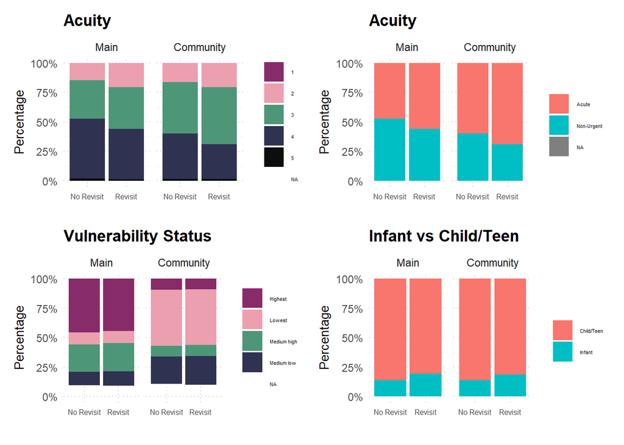

```r
ggdraw() +
  draw_plot(acuityplot, x=0, y=0.5, width = 0.5, height = 0.5)+
  draw_plot(esigpplot, x=0.5, y=0.5, width = 0.5, height = 0.5)+
  draw_plot(sviplot, x=0, y=0, width = 0.5, height = 0.5)+
  draw_plot(agecatplot, x=0.5, y=0, width = 0.5, height = 0.5)+
  theme_minimal()
```

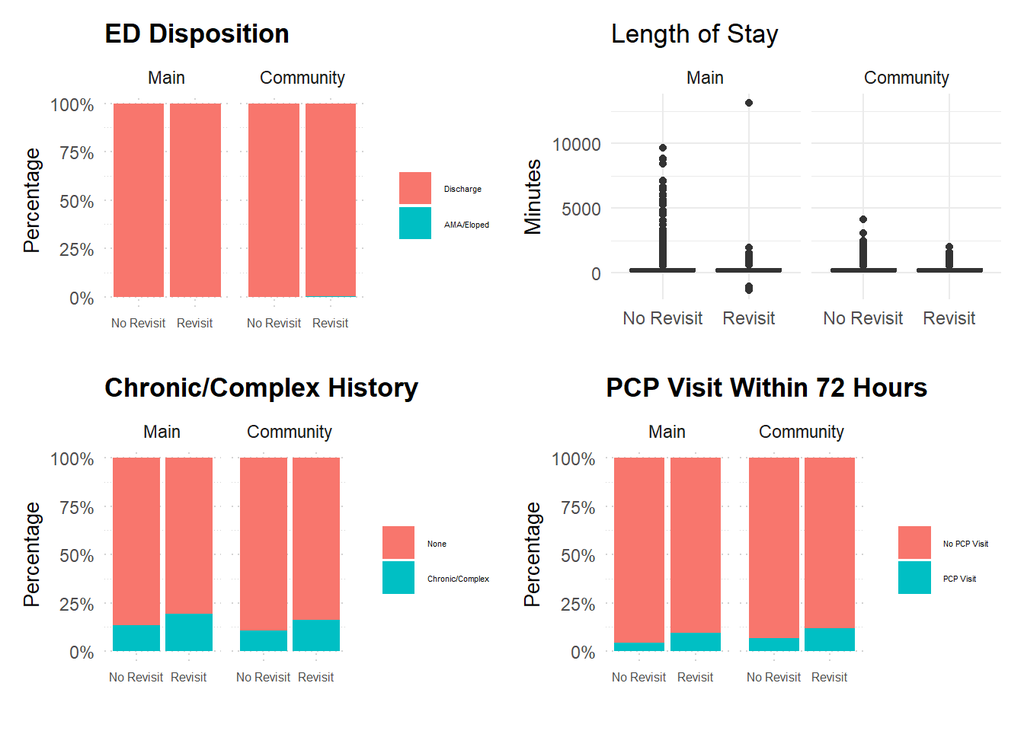

```r
ggdraw() +
  draw_plot(dispoplot, x=0, y=0.5, width = 0.5, height = 0.5)+
  draw_plot(LOSplot, x=0.5, y=0.5, width = 0.5, height = 0.5)+
  draw_plot(chronicplot, x=0, y=0, width = 0.5, height = 0.5)+
  draw_plot(pcpplot, x=0.5, y=0, width = 0.5, height = 0.5)+
  theme_minimal()
```

### 4.2 Preliminary Analysis

*Categorical/Continuous Variables*

Race/Ethnicity (p<.001)  
Insurance type (p<.0012)  
Vulnerability Status (p<.001)  
Acuity (p<.001)  
Arrival time (categorical) (p<.001)

*Dichotomous Variables*

Age (p<.001)  
Acuity (Dichotomous) (p<.001)  
Complex Condition (p<.001)  
PCP within 72 Hours (p<.001)  
Campus (p<.001)  
Disposition type (p<.001)

```r
#Categorical/Continuous Variables
#Race/Ethnicity:
chisq.test(table(data$REVISIT_72_HR, data$eth_cat))
```

```
    Pearson's Chi-squared test

data:  table(data$REVISIT_72_HR, data$eth_cat)
X-squared = 27.221, df = 3, p-value = 5.291e-06
```

```r
#Language
chisq.test(table(data$REVISIT_72_HR, data$LANGIND))
```

```
    Pearson's Chi-squared test with Yates' continuity correction

data:  table(data$REVISIT_72_HR, data$LANGIND)
X-squared = 1.8652, df = 1, p-value = 0.172
```

```r
#Insurance
chisq.test(table(data$REVISIT_72_HR, data$PAYOR_GROUP))
```

```
    Pearson's Chi-squared test

data:  table(data$REVISIT_72_HR, data$PAYOR_GROUP)
X-squared = 16.044, df = 3, p-value = 0.001111
```

```r
#Vulnerability
chisq.test(table(data$REVISIT_72_HR, data$SVI_CATEGORY))
```

```
    Pearson's Chi-squared test

data:  table(data$REVISIT_72_HR, data$SVI_CATEGORY)
X-squared = 22.806, df = 3, p-value = 4.432e-05
```

```r
#Acuity (Categorical)
chisq.test(table(data$REVISIT_72_HR, data$ACUITY))
```

```
    Pearson's Chi-squared test

data:  table(data$REVISIT_72_HR, data$ACUITY)
X-squared = 381.29, df = 4, p-value < 2.2e-16
```

```r
#Arrival
chisq.test(table(data$REVISIT_72_HR, data$Arrival))
```

```
    Pearson's Chi-squared test

data:  table(data$REVISIT_72_HR, data$Arrival)
X-squared = 52.847, df = 2, p-value = 3.345e-12
```

```r
#ED Volume
chisq.test(table(data$REVISIT_72_HR, data$volume))
```

```
    Pearson's Chi-squared test

data:  table(data$REVISIT_72_HR, data$volume)
X-squared = 11.759, df = 3, p-value = 0.008258
```

```r
#Dichtomous Variables
#Sex: *Dichotomous for ease of analysis and 2/2 lack of reliable gender identity data
chisq.test(table(data$REVISIT_72_HR, data$SEX))
```

```
    Pearson's Chi-squared test with Yates' continuity correction

data:  table(data$REVISIT_72_HR, data$SEX)
X-squared = 0.049861, df = 1, p-value = 0.8233
```

```r
#Age(Dichotomous)
chisq.test(table(data$REVISIT_72_HR, data$age_cat))
```

```
    Pearson's Chi-squared test with Yates' continuity correction

data:  table(data$REVISIT_72_HR, data$age_cat)
X-squared = 223.86, df = 1, p-value < 2.2e-16
```

```r
#Acuity (Dichotomous)
chisq.test(table(data$REVISIT_72_HR, data$esigp))
```

```
    Pearson's Chi-squared test with Yates' continuity correction

data:  table(data$REVISIT_72_HR, data$esigp)
X-squared = 315.57, df = 1, p-value < 2.2e-16
```

```r
#Complex/Chronic
chisq.test(table(data$REVISIT_72_HR, data$COMPLEX_CHRONIC_CONDITION_IND))
```

```
    Pearson's Chi-squared test with Yates' continuity correction

data:  table(data$REVISIT_72_HR, data$COMPLEX_CHRONIC_CONDITION_IND)
X-squared = 261.46, df = 1, p-value < 2.2e-16
```

```r
#PCP Visit
chisq.test(table(data$REVISIT_72_HR, data$PCP_VISIT_72_HR))
```

```
    Pearson's Chi-squared test with Yates' continuity correction

data:  table(data$REVISIT_72_HR, data$PCP_VISIT_72_HR)
X-squared = 495.45, df = 1, p-value < 2.2e-16
```

```r
#Campus
chisq.test(table(data$REVISIT_72_HR, data$CAMPUS))
```

```
    Pearson's Chi-squared test with Yates' continuity correction

data:  table(data$REVISIT_72_HR, data$CAMPUS)
X-squared = 44.6, df = 1, p-value = 2.417e-11
```

```r
#ED Disposition
chisq.test(table(data$REVISIT_72_HR, data$ED_DISPOSITION))
```

```
    Pearson's Chi-squared test with Yates' continuity correction

data:  table(data$REVISIT_72_HR, data$ED_DISPOSITION)
X-squared = 39.239, df = 1, p-value = 3.75e-10
```

#### 4.2.1 Univariable Logistic Regression

*Categorical/Continuous*

*Dichotomous Variables*

Age: Infant (p<.001)  
Acuity: Non-Urgent (p<.001)  
Chronic/Complex (p<.001)  
PCP Visit w/in 72hrs (p<.001)  
ED Disposition: AMA/Eloped (p<.001)  
Campus: Community (p<.001)

```r
#Categorical/Continuous Variables
#Age (Continuous)
summary((glm(REVISIT_72_HR ~ AGE_AT_VISIT, data = data, family = binomial())))
```

```
Call:
glm(formula = REVISIT_72_HR ~ AGE_AT_VISIT, family = binomial(),
    data = data)

Coefficients:
              Estimate Std. Error z value Pr(>|z|)
(Intercept)  -2.855494   0.015865  -180.0   <2e-16 ***
AGE_AT_VISIT -0.029025   0.002043   -14.2   <2e-16 ***
---
Signif. codes:  0 '***' 0.001 '**' 0.01 '*' 0.05 '.' 0.1 ' ' 1

(Dispersion parameter for binomial family taken to be 1)

    Null deviance: 78724  on 211583  degrees of freedom
Residual deviance: 78515  on 211582  degrees of freedom
AIC: 78519

Number of Fisher Scoring iterations: 6
```

```r
exp(coef(glm(REVISIT_72_HR ~ AGE_AT_VISIT, data = data, family = binomial())))
```

```
 (Intercept) AGE_AT_VISIT
  0.05752738   0.97139243
```

```r
#Length of Stay (Continuous)
summary((glm(REVISIT_72_HR ~ ED_LOS, data = data, family = binomial())))
```

```
Call:
glm(formula = REVISIT_72_HR ~ ED_LOS, family = binomial(), data = data)

Coefficients:
              Estimate Std. Error  z value Pr(>|z|)
(Intercept) -3.142e+00  1.523e-02 -206.381   <2e-16 ***
ED_LOS       4.495e-04  4.576e-05    9.824   <2e-16 ***
---
Signif. codes:  0 '***' 0.001 '**' 0.01 '*' 0.05 '.' 0.1 ' ' 1

(Dispersion parameter for binomial family taken to be 1)

    Null deviance: 78724  on 211573  degrees of freedom
Residual deviance: 78633  on 211572  degrees of freedom
  (10 observations deleted due to missingness)
AIC: 78637

Number of Fisher Scoring iterations: 5
```

```r
exp(coef(glm(REVISIT_72_HR ~ ED_LOS, data = data, family = binomial())))
```

```
(Intercept)      ED_LOS
 0.04318245  1.00044963
```

```r
#Race:
summary((glm(REVISIT_72_HR ~ eth_cat, data = data, family = binomial())))
```

```
Call:
glm(formula = REVISIT_72_HR ~ eth_cat, family = binomial(), data = data)

Coefficients:
                       Estimate Std. Error  z value Pr(>|z|)
(Intercept)            -2.97350    0.01936 -153.588  < 2e-16 ***
eth_catBlack           -0.12330    0.02524   -4.884 1.04e-06 ***
eth_catHispanic/Latino -0.02078    0.03291   -0.632    0.528
eth_catOther           -0.04884    0.03330   -1.466    0.143
---
Signif. codes:  0 '***' 0.001 '**' 0.01 '*' 0.05 '.' 0.1 ' ' 1

(Dispersion parameter for binomial family taken to be 1)

    Null deviance: 78724  on 211577  degrees of freedom
Residual deviance: 78697  on 211574  degrees of freedom
  (6 observations deleted due to missingness)
AIC: 78705

Number of Fisher Scoring iterations: 5
```

```r
exp(coef(glm(REVISIT_72_HR ~ eth_cat, data = data, family = binomial())))
```

```
           (Intercept)           eth_catBlack eth_catHispanic/Latino
            0.05112404             0.88399603             0.97943350
          eth_catOther
            0.95233779
```

```r
#Insurance
summary((glm(REVISIT_72_HR ~ PAYOR_GROUP, data = data, family = binomial())))
```

```
Call:
glm(formula = REVISIT_72_HR ~ PAYOR_GROUP, family = binomial(),
    data = data)

Coefficients:
                        Estimate Std. Error  z value Pr(>|z|)
(Intercept)             -3.04346    0.01727 -176.261  < 2e-16 ***
PAYOR_GROUPGovernment    0.01845    0.02169    0.851 0.394975
PAYOR_GROUPCharity Care -0.19739    0.34023   -0.580 0.561804
PAYOR_GROUPSelf Pay     -0.44554    0.12006   -3.711 0.000206 ***
---
Signif. codes:  0 '***' 0.001 '**' 0.01 '*' 0.05 '.' 0.1 ' ' 1

(Dispersion parameter for binomial family taken to be 1)

    Null deviance: 78667  on 211485  degrees of freedom
Residual deviance: 78649  on 211482  degrees of freedom
  (98 observations deleted due to missingness)
AIC: 78657

Number of Fisher Scoring iterations: 6
```

```r
exp(coef(glm(REVISIT_72_HR ~ PAYOR_GROUP, data = data, family = binomial())))
```

```
            (Intercept)   PAYOR_GROUPGovernment PAYOR_GROUPCharity Care
             0.04766943              1.01861755              0.82087056
    PAYOR_GROUPSelf Pay
             0.64047663
```

```r
#Vulnerability
summary((glm(REVISIT_72_HR ~ SVI_CATEGORY, data = data, family = binomial())))
```

```
Call:
glm(formula = REVISIT_72_HR ~ SVI_CATEGORY, family = binomial(),
    data = data)

Coefficients:
                        Estimate Std. Error  z value Pr(>|z|)
(Intercept)             -3.09435    0.01774 -174.441  < 2e-16 ***
SVI_CATEGORYLowest       0.10444    0.02891    3.613 0.000303 ***
SVI_CATEGORYMedium high  0.08103    0.02927    2.769 0.005627 **
SVI_CATEGORYMedium low   0.12918    0.03180    4.063 4.85e-05 ***
---
Signif. codes:  0 '***' 0.001 '**' 0.01 '*' 0.05 '.' 0.1 ' ' 1

(Dispersion parameter for binomial family taken to be 1)

    Null deviance: 71229  on 190849  degrees of freedom
Residual deviance: 71206  on 190846  degrees of freedom
  (20734 observations deleted due to missingness)
AIC: 71214

Number of Fisher Scoring iterations: 5
```

```r
exp(coef(glm(REVISIT_72_HR ~ SVI_CATEGORY, data = data, family = binomial())))
```

```
            (Intercept)      SVI_CATEGORYLowest SVI_CATEGORYMedium high
             0.04530449              1.11008912              1.08440313
 SVI_CATEGORYMedium low
             1.13789327
```

```r
#Acuity (categorical)
summary((glm(REVISIT_72_HR ~ ACUITY, data = data, family = binomial())))
```

```
Call:
glm(formula = REVISIT_72_HR ~ ACUITY, family = binomial(), data = data)

Coefficients:
            Estimate Std. Error z value Pr(>|z|)
(Intercept)  -3.1355     0.3861  -8.121 4.62e-16 ***
ACUITY2       0.4100     0.3868   1.060    0.289
ACUITY3       0.2014     0.3865   0.521    0.602
ACUITY4      -0.1012     0.3864  -0.262    0.793
ACUITY5      -0.2608     0.3963  -0.658    0.511
---
Signif. codes:  0 '***' 0.001 '**' 0.01 '*' 0.05 '.' 0.1 ' ' 1

(Dispersion parameter for binomial family taken to be 1)

    Null deviance: 78717  on 211572  degrees of freedom
Residual deviance: 78343  on 211568  degrees of freedom
  (11 observations deleted due to missingness)
AIC: 78353

Number of Fisher Scoring iterations: 6
```

```r
exp(coef(glm(REVISIT_72_HR ~ ACUITY, data = data, family = binomial())))
```

```
(Intercept)     ACUITY2     ACUITY3     ACUITY4     ACUITY5
 0.04347826  1.50680982  1.22315784  0.90377039  0.77044923
```

```r
#Arrival
summary((glm(REVISIT_72_HR ~ Arrival, data = data, family = binomial())))
```

```
Call:
glm(formula = REVISIT_72_HR ~ Arrival, family = binomial(), data = data)

Coefficients:
                 Estimate Std. Error  z value Pr(>|z|)
(Intercept)      -3.07347    0.01669 -184.101  < 2e-16 ***
ArrivalEvening    0.01374    0.02272    0.605    0.545
ArrivalOvernight  0.21387    0.03107    6.884 5.82e-12 ***
---
Signif. codes:  0 '***' 0.001 '**' 0.01 '*' 0.05 '.' 0.1 ' ' 1

(Dispersion parameter for binomial family taken to be 1)

    Null deviance: 78724  on 211583  degrees of freedom
Residual deviance: 78674  on 211581  degrees of freedom
AIC: 78680

Number of Fisher Scoring iterations: 5
```

```r
exp(coef(glm(REVISIT_72_HR ~ Arrival, data = data, family = binomial())))
```

```
     (Intercept)   ArrivalEvening ArrivalOvernight
      0.04626023       1.01383623       1.23846474
```

```r
#Volume
summary((glm(REVISIT_72_HR ~ volume, data = data, family = binomial())))
```

```
Call:
glm(formula = REVISIT_72_HR ~ volume, family = binomial(), data = data)

Coefficients:
                  Estimate Std. Error  z value Pr(>|z|)
(Intercept)       -3.11023    0.02523 -123.258  < 2e-16 ***
volumeLow          0.10889    0.03228    3.373 0.000743 ***
volumeMedium-High  0.06626    0.03298    2.009 0.044533 *
volumeMedium-Low   0.08119    0.03249    2.499 0.012463 *
---
Signif. codes:  0 '***' 0.001 '**' 0.01 '*' 0.05 '.' 0.1 ' ' 1

(Dispersion parameter for binomial family taken to be 1)

    Null deviance: 73572  on 198350  degrees of freedom
Residual deviance: 73561  on 198347  degrees of freedom
  (13233 observations deleted due to missingness)
AIC: 73569

Number of Fisher Scoring iterations: 5
```

```r
exp(coef(glm(REVISIT_72_HR ~ volume, data = data, family = binomial())))
```

```
      (Intercept)         volumeLow volumeMedium-High  volumeMedium-Low
       0.04459067        1.11504445        1.06850682        1.08458005
```

```r
#Dichtomous Variables

#Sex: *Dichotomous for ease of analysis and 2/2 lack of reliable gender identity data
summary((glm(REVISIT_72_HR ~ SEX, data = data, family = binomial())))
```

```
Call:
glm(formula = REVISIT_72_HR ~ SEX, family = binomial(), data = data)

Coefficients:
             Estimate Std. Error  z value Pr(>|z|)
(Intercept) -3.033632   0.014316 -211.902   <2e-16 ***
SEXFemale   -0.004867   0.020822   -0.234    0.815
---
Signif. codes:  0 '***' 0.001 '**' 0.01 '*' 0.05 '.' 0.1 ' ' 1

(Dispersion parameter for binomial family taken to be 1)

    Null deviance: 78723  on 211570  degrees of freedom
Residual deviance: 78723  on 211569  degrees of freedom
  (13 observations deleted due to missingness)
AIC: 78727

Number of Fisher Scoring iterations: 5
```

```r
exp(coef(glm(REVISIT_72_HR ~ SEX, data = data, family = binomial())))
```

```
(Intercept)   SEXFemale
 0.04814048  0.99514508
```

```r
#Age(Dichotomous)
summary((glm(REVISIT_72_HR ~ age_cat, data = data, family = binomial())))
```

```
Call:
glm(formula = REVISIT_72_HR ~ age_cat, family = binomial(), data = data)

Coefficients:
              Estimate Std. Error z value Pr(>|z|)
(Intercept)   -3.10071    0.01155 -268.54   <2e-16 ***
age_catInfant  0.39600    0.02660   14.89   <2e-16 ***
---
Signif. codes:  0 '***' 0.001 '**' 0.01 '*' 0.05 '.' 0.1 ' ' 1

(Dispersion parameter for binomial family taken to be 1)

    Null deviance: 78724  on 211583  degrees of freedom
Residual deviance: 78519  on 211582  degrees of freedom
AIC: 78523

Number of Fisher Scoring iterations: 6
```

```r
exp(coef(glm(REVISIT_72_HR ~ age_cat, data = data, family = binomial())))
```

```
  (Intercept) age_catInfant
   0.04501726    1.48587174
```

```r
#Acuity(Dichotomous)
summary((glm(REVISIT_72_HR ~ esigp, data = data, family = binomial())))
```

```
Call:
glm(formula = REVISIT_72_HR ~ esigp, family = binomial(), data = data)

Coefficients:
                Estimate Std. Error z value Pr(>|z|)
(Intercept)     -2.86786    0.01351 -212.20   <2e-16 ***
esigpNon-Urgent -0.37450    0.02118  -17.68   <2e-16 ***
---
Signif. codes:  0 '***' 0.001 '**' 0.01 '*' 0.05 '.' 0.1 ' ' 1

(Dispersion parameter for binomial family taken to be 1)

    Null deviance: 78717  on 211572  degrees of freedom
Residual deviance: 78399  on 211571  degrees of freedom
  (11 observations deleted due to missingness)
AIC: 78403

Number of Fisher Scoring iterations: 6
```

```r
exp(coef(glm(REVISIT_72_HR ~ esigp, data = data, family = binomial())))
```

```
    (Intercept) esigpNon-Urgent
     0.05682019      0.68762962
```

```r
#Language
summary((glm(REVISIT_72_HR ~ LANGIND, data = data, family = binomial())))
```

```
Call:
glm(formula = REVISIT_72_HR ~ LANGIND, family = binomial(), data = data)

Coefficients:
             Estimate Std. Error  z value Pr(>|z|)
(Intercept)  -3.03155    0.01086 -279.098   <2e-16 ***
LANGINDOther -0.05186    0.03747   -1.384    0.166
---
Signif. codes:  0 '***' 0.001 '**' 0.01 '*' 0.05 '.' 0.1 ' ' 1

(Dispersion parameter for binomial family taken to be 1)

    Null deviance: 78724  on 211583  degrees of freedom
Residual deviance: 78723  on 211582  degrees of freedom
AIC: 78727

Number of Fisher Scoring iterations: 5
```

```r
exp(coef(glm(REVISIT_72_HR ~ LANGIND, data = data, family = binomial())))
```

```
 (Intercept) LANGINDOther
  0.04824099   0.94945844
```

```r
#Complex/Chronic
summary((glm(REVISIT_72_HR ~ COMPLEX_CHRONIC_CONDITION_IND, data = data, family = binomial())))
```

```
Call:
glm(formula = REVISIT_72_HR ~ COMPLEX_CHRONIC_CONDITION_IND,
    family = binomial(), data = data)

Coefficients:
                                             Estimate Std. Error z value
(Intercept)                                  -3.10337    0.01150 -269.84
COMPLEX_CHRONIC_CONDITION_INDChronic/Complex  0.43346    0.02697   16.07
                                             Pr(>|z|)
(Intercept)                                    <2e-16 ***
COMPLEX_CHRONIC_CONDITION_INDChronic/Complex   <2e-16 ***
---
Signif. codes:  0 '***' 0.001 '**' 0.01 '*' 0.05 '.' 0.1 ' ' 1

(Dispersion parameter for binomial family taken to be 1)

    Null deviance: 78724  on 211583  degrees of freedom
Residual deviance: 78487  on 211582  degrees of freedom
AIC: 78491

Number of Fisher Scoring iterations: 6
```

```r
exp(coef(glm(REVISIT_72_HR ~ COMPLEX_CHRONIC_CONDITION_IND, data = data, family = binomial())))
```

```
                                 (Intercept)
                                  0.04489759
COMPLEX_CHRONIC_CONDITION_INDChronic/Complex
                                  1.54257862
```

```r
#PCP Visit
summary((glm(REVISIT_72_HR ~ PCP_VISIT_72_HR, data = data, family = binomial())))
```

```
Call:
glm(formula = REVISIT_72_HR ~ PCP_VISIT_72_HR, family = binomial(),
    data = data)

Coefficients:
                         Estimate Std. Error z value Pr(>|z|)
(Intercept)              -3.09176    0.01095 -282.26   <2e-16 ***
PCP_VISIT_72_HRPCP Visit  0.76565    0.03517   21.77   <2e-16 ***
---
Signif. codes:  0 '***' 0.001 '**' 0.01 '*' 0.05 '.' 0.1 ' ' 1

(Dispersion parameter for binomial family taken to be 1)

    Null deviance: 78724  on 211583  degrees of freedom
Residual deviance: 78325  on 211582  degrees of freedom
AIC: 78329

Number of Fisher Scoring iterations: 6
```

```r
exp(coef(glm(REVISIT_72_HR ~ PCP_VISIT_72_HR, data = data, family = binomial())))
```

```
             (Intercept) PCP_VISIT_72_HRPCP Visit
              0.04542185               2.15039439
```

```r
#ED Disposition
summary((glm(REVISIT_72_HR ~ ED_DISPOSITION, data = data, family = binomial())))
```

```
Call:
glm(formula = REVISIT_72_HR ~ ED_DISPOSITION, family = binomial(),
    data = data)

Coefficients:
                         Estimate Std. Error  z value Pr(>|z|)
(Intercept)               -3.0371     0.0104 -291.969  < 2e-16 ***
ED_DISPOSITIONAMA/Eloped   1.8179     0.3159    5.756 8.63e-09 ***
---
Signif. codes:  0 '***' 0.001 '**' 0.01 '*' 0.05 '.' 0.1 ' ' 1

(Dispersion parameter for binomial family taken to be 1)

    Null deviance: 78724  on 211583  degrees of freedom
Residual deviance: 78701  on 211582  degrees of freedom
AIC: 78705

Number of Fisher Scoring iterations: 5
```

```r
exp(coef(glm(REVISIT_72_HR ~ ED_DISPOSITION, data = data, family = binomial())))
```

```
             (Intercept) ED_DISPOSITIONAMA/Eloped
              0.04797269               6.15880676
```

```r
#Campus
summary((glm(REVISIT_72_HR ~ CAMPUS, data = data, family = binomial())))
```

```
Call:
glm(formula = REVISIT_72_HR ~ CAMPUS, family = binomial(), data = data)

Coefficients:
                Estimate Std. Error  z value Pr(>|z|)
(Intercept)     -3.07752    0.01228 -250.666  < 2e-16 ***
CAMPUSCommunity  0.15430    0.02308    6.685 2.31e-11 ***
---
Signif. codes:  0 '***' 0.001 '**' 0.01 '*' 0.05 '.' 0.1 ' ' 1

(Dispersion parameter for binomial family taken to be 1)

    Null deviance: 78724  on 211583  degrees of freedom
Residual deviance: 78681  on 211582  degrees of freedom
AIC: 78685

Number of Fisher Scoring iterations: 5
```

```r
exp(coef(glm(REVISIT_72_HR ~ CAMPUS, data = data, family = binomial())))
```

```
    (Intercept) CAMPUSCommunity
     0.04607334      1.16683716
```

```r
m1 <- glm(REVISIT_72_HR ~ SEX + age_cat + eth_cat + LANGIND + ED_LOS + PAYOR_GROUP + SVI_CATEGORY + esigp + COMPLEX_CHRONIC_CONDITION_IND + Arrival + ED_DISPOSITION + CAMPUS + PCP_VISIT_72_HR + volume, data = data, family = binomial())
```

```r
t3 <- tbl_regression(m1, exponentiate = TRUE) %>%
  bold_p(t = 0.05) %>%
  bold_labels() %>%
  italicize_levels()
t3
```

| **Characteristic** | **OR**<sup>1</sup> | **95% CI**<sup>1</sup> | **p-value** |
| --- | --- | --- | --- |
| Sex |  |  |  |
| Male | — | — |  |
| Female | 1.00 | 0.96, 1.05 | 0.8 |
| Age (Categorical) |  |  |  |
| Child/Teen | — | — |  |
| Infant | 1.39 | 1.31, 1.48 | <0.001 |
| Race/Ethnicity |  |  |  |
| White | — | — |  |
| Black | 0.92 | 0.86, 0.99 | 0.027 |
| Hispanic/Latino | 1.01 | 0.92, 1.09 | >0.9 |
| Other | 0.98 | 0.91, 1.06 | 0.6 |
| Language |  |  |  |
| English | — | — |  |
| Other | 0.95 | 0.87, 1.04 | 0.3 |
| Length of Stay | 1.00 | 1.00, 1.00 | <0.001 |
| Insurance Type |  |  |  |
| Commercial | — | — |  |
| Government | 1.17 | 1.11, 1.24 | <0.001 |
| Charity Care | 1.05 | 0.47, 2.00 | 0.9 |
| Self Pay | 0.79 | 0.59, 1.03 | 0.10 |
| Vulnerability Score |  |  |  |
| Highest | — | — |  |
| Lowest | 0.97 | 0.89, 1.04 | 0.4 |
| Medium high | 1.05 | 0.99, 1.11 | 0.10 |
| Medium low | 1.02 | 0.95, 1.10 | 0.5 |
| Acuity (Dichotomized) |  |  |  |
| Acute | — | — |  |
| Non-Urgent | 0.78 | 0.74, 0.82 | <0.001 |
| Complex or Chronic History |  |  |  |
| None | — | — |  |
| Chronic/Complex | 1.45 | 1.37, 1.53 | <0.001 |
| Arrival |  |  |  |
| Daytime | — | — |  |
| Evening | 1.00 | 0.96, 1.05 | 0.9 |
| Overnight | 1.18 | 1.11, 1.27 | <0.001 |
| Disposition from ED |  |  |  |
| Discharge | — | — |  |
| AMA/Eloped | 5.73 | 2.74, 11.1 | <0.001 |
| Campus |  |  |  |
| Main | — | — |  |
| Community | 1.18 | 1.11, 1.26 | <0.001 |
| PCP Visit within 72 Hours |  |  |  |
| No PCP Visit | — | — |  |
| PCP Visit | 1.99 | 1.84, 2.14 | <0.001 |
| ED Volume (Categorical) |  |  |  |
| High | — | — |  |
| Low | 1.09 | 1.02, 1.17 | 0.013 |
| Medium-High | 1.02 | 0.96, 1.10 | 0.5 |
| Medium-Low | 1.04 | 0.97, 1.11 | 0.3 |

<sup>1</sup> OR = Odds Ratio, CI = Confidence Interval

```r
glm.pred <- predict(m1, data, type = "response")
head(glm.pred)
```

```
         1          2          3          4          5          6
0.03389379 0.03179719 0.04560049         NA 0.10694976 0.04603689
```

```r
#K Fold Cross Validation
N = nrow(data)
K = 10
set.seed(1234)
s = sample(1:K, size = N, replace = T)
pred.outputs.glm <- vector(mode = "numeric", length = N)
obs.outputs <- vector(mode = "numeric", length = N)
offset<- 0

for (i in 1:K){
  train <- filter(data, s != i)
  test <- filter(data, s == i)
  obs.outputs[1:length(s[s == i]) + offset] <- test$REVISIT_72_HR

  # GLM train/test
  glm <- glm(REVISIT_72_HR ~ SEX + age_cat + eth_cat + LANGIND + ED_LOS + PAYOR_GROUP + SVI_CATEGORY + esigp + COMPLEX_CHRONIC_CONDITION_IND + Arrival + ED_DISPOSITION + CAMPUS + PCP_VISIT_72_HR + volume, data = data, family = binomial(logit))
  glm.pred.curr <- predict(glm, test, type = "response")
  pred.outputs.glm[1:length(s[s == i]) + offset] <- glm.pred.curr

  offset <- offset + length(s[s == i])
}
head(cbind(pred.outputs.glm, obs.outputs))
```

```
     pred.outputs.glm obs.outputs
[1,]       0.03114020           1
[2,]       0.03826561           1
[3,]               NA           1
[4,]               NA           1
[5,]       0.03340577           1
[6,]       0.05191439           1
```

```r
roc(data$REVISIT_72_HR, glm.pred, ci = TRUE)
```

```
Call:
roc.default(response = data$REVISIT_72_HR, predictor = glm.pred,     ci = TRUE)

Data: glm.pred in 170970 controls (data$REVISIT_72_HR No Revisit) < 8201 cases (data$REVISIT_72_HR Revisit).
Area under the curve: 0.5974
95% CI: 0.591-0.6038 (DeLong)
```

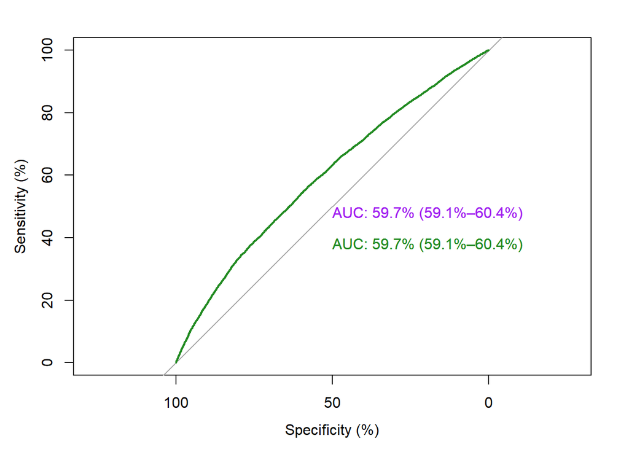

```r
plot.roc(data$REVISIT_72_HR, glm.pred, percent = TRUE, col = "purple", print.auc= TRUE, ci = TRUE) #graph that corresponds to that
plot.roc(obs.outputs, pred.outputs.glm, percent = TRUE, print.auc = TRUE, print.auc.y = 40, ci = TRUE, col = "forestgreen", add = TRUE) #observed data. cross validation curve is almost the same
```